# **Time Series Analysis on ENSO Using Prophet’s Forecasting Framework**

# Chapter 3: Forecasting with Prophet

## We can now finally start working with Prophet!

```
## starting httpd help server ... done
```

## We must first convert our time series into a data frame.

## This data frame needs to have two columns for Prophet to recognise it: ds (the dates) and y (the respective data values). We will need to run the library zoo.

```r
library(zoo) # for the yearmon() function
```

```r
df <- data.frame(ds = as.Date(as.yearmon(time(ENSO))), y = as.numeric(ENSO))
df # I'm checking to see if the dates line up, because when running '?ENSO', the description did not explicitly state that the data values were taken on a daily basis
```

```r
head(df) # shows us the first six rows of the data frame
```

```
##           ds          y
## 1 1951-01-01  2.0078001
## 2 1951-02-01  1.1232886
## 3 1951-03-01 -0.3175287
## 4 1951-04-01 -0.8057669
## 5 1951-05-01 -1.1422184
## 6 1951-06-01 -0.6555559
```

```r
p_df = prophet(df)
```

```
## Disabling weekly seasonality. Run prophet with weekly.seasonality=TRUE to override this.
```

```
## Disabling daily seasonality. Run prophet with daily.seasonality=TRUE to override this.
```

```r
# Let's create future dates for forecasting.
NextYear = make_future_dataframe(p_df, 1825); NextYear
```

```r
# Now we can use Prophet's predict function!
pdfForecast = predict(p_df, NextYear); pdfForecast
```

```r
# To check our results at each step:
head(pdfForecast)
```

```
##           ds     trend additive_terms additive_terms_lower additive_terms_upper
## 1 1951-01-01 0.1965473      0.4097131            0.4097131            0.4097131
## 2 1951-02-01 0.1962428      0.4233504            0.4233504            0.4233504
## 3 1951-03-01 0.1959677      0.2206992            0.2206992            0.2206992
## 4 1951-04-01 0.1956631     -0.3886839           -0.3886839           -0.3886839
## 5 1951-05-01 0.1953684     -0.4813202           -0.4813202           -0.4813202
## 6 1951-06-01 0.1950638     -0.4674402           -0.4674402           -0.4674402
##       yearly yearly_lower yearly_upper multiplicative_terms
## 1  0.4097131    0.4097131    0.4097131                    0
## 2  0.4233504    0.4233504    0.4233504                    0
## 3  0.2206992    0.2206992    0.2206992                    0
## 4 -0.3886839   -0.3886839   -0.3886839                    0
## 5 -0.4813202   -0.4813202   -0.4813202                    0
## 6 -0.4674402   -0.4674402   -0.4674402                    0
##   multiplicative_terms_lower multiplicative_terms_upper yhat_lower yhat_upper
## 1                          0                          0 -0.5127387  1.8192395
## 2                          0                          0 -0.5813001  1.7932461
## 3                          0                          0 -0.7389460  1.5642818
## 4                          0                          0 -1.3897659  0.9001891
## 5                          0                          0 -1.4286603  0.9736851
## 6                          0                          0 -1.3844633  0.8724310
##   trend_lower trend_upper       yhat
## 1   0.1965473   0.1965473  0.6062605
## 2   0.1962428   0.1962428  0.6195931
## 3   0.1959677   0.1959677  0.4166669
## 4   0.1956631   0.1956631 -0.1930208
## 5   0.1953684   0.1953684 -0.2859518
## 6   0.1950638   0.1950638 -0.2723764
```

```r
tail(pdfForecast)
```

```
##              ds     trend additive_terms additive_terms_lower
## 2682 2027-09-25 0.4388667      0.0880302            0.0880302
## 2683 2027-09-26 0.4388945      0.1173226            0.1173226
## 2684 2027-09-27 0.4389224      0.1492458            0.1492458
## 2685 2027-09-28 0.4389502      0.1829257            0.1829257
## 2686 2027-09-29 0.4389781      0.2174284            0.2174284
## 2687 2027-09-30 0.4390059      0.2517861            0.2517861
##      additive_terms_upper    yearly yearly_lower yearly_upper
## 2682            0.0880302 0.0880302    0.0880302    0.0880302
## 2683            0.1173226 0.1173226    0.1173226    0.1173226
## 2684            0.1492458 0.1492458    0.1492458    0.1492458
## 2685            0.1829257 0.1829257    0.1829257    0.1829257
## 2686            0.2174284 0.2174284    0.2174284    0.2174284
## 2687            0.2517861 0.2517861    0.2517861    0.2517861
##      multiplicative_terms multiplicative_terms_lower multiplicative_terms_upper
## 2682                    0                          0                          0
## 2683                    0                          0                          0
## 2684                    0                          0                          0
## 2685                    0                          0                          0
## 2686                    0                          0                          0
## 2687                    0                          0                          0
##      yhat_lower yhat_upper trend_lower trend_upper      yhat
## 2682 -0.7234377   1.677222   0.4357125   0.4423494 0.5268969
## 2683 -0.5942350   1.775323   0.4357379   0.4423789 0.5562171
## 2684 -0.5975760   1.634045   0.4357633   0.4424084 0.5881682
## 2685 -0.4908706   1.867055   0.4357886   0.4424380 0.6218759
## 2686 -0.5623703   1.773384   0.4358140   0.4424675 0.6564064
## 2687 -0.5140400   1.847870   0.4358394   0.4424970 0.6907921
```

```r
summary(pdfForecast$yhat) # to check min, max, mean, variance
```

```
##     Min.  1st Qu.   Median     Mean  3rd Qu.     Max.
## -0.40125  0.05968  0.36681  0.33364  0.60073  1.08276
```

```r
str(pdfForecast)
```

```
## 'data.frame':    2687 obs. of  16 variables:
##  $ ds                        : POSIXct, format: "1951-01-01" "1951-02-01" ...
##  $ trend                     : num  0.197 0.196 0.196 0.196 0.195 ...
##  $ additive_terms            : num  0.41 0.423 0.221 -0.389 -0.481 ...
##  $ additive_terms_lower      : num  0.41 0.423 0.221 -0.389 -0.481 ...
##  $ additive_terms_upper      : num  0.41 0.423 0.221 -0.389 -0.481 ...
##  $ yearly                    : num  0.41 0.423 0.221 -0.389 -0.481 ...
##  $ yearly_lower              : num  0.41 0.423 0.221 -0.389 -0.481 ...
##  $ yearly_upper              : num  0.41 0.423 0.221 -0.389 -0.481 ...
##  $ multiplicative_terms      : num  0 0 0 0 0 0 0 0 0 0 ...
##  $ multiplicative_terms_lower: num  0 0 0 0 0 0 0 0 0 0 ...
##  $ multiplicative_terms_upper: num  0 0 0 0 0 0 0 0 0 0 ...
##  $ yhat_lower                : num  -0.513 -0.581 -0.739 -1.39 -1.429 ...
##  $ yhat_upper                : num  1.819 1.793 1.564 0.9 0.974 ...
##  $ trend_lower               : num  0.197 0.196 0.196 0.196 0.195 ...
##  $ trend_upper               : num  0.197 0.196 0.196 0.196 0.195 ...
##  $ yhat                      : num  0.606 0.62 0.417 -0.193 -0.286 ...
```

# Chapter 4: Plotting the forecast using ggplot2

## We can now plot this; it should be noted that historical data and predictions should clearly be distinguished by some sort of visual difference. In this case, I will put a separation line.

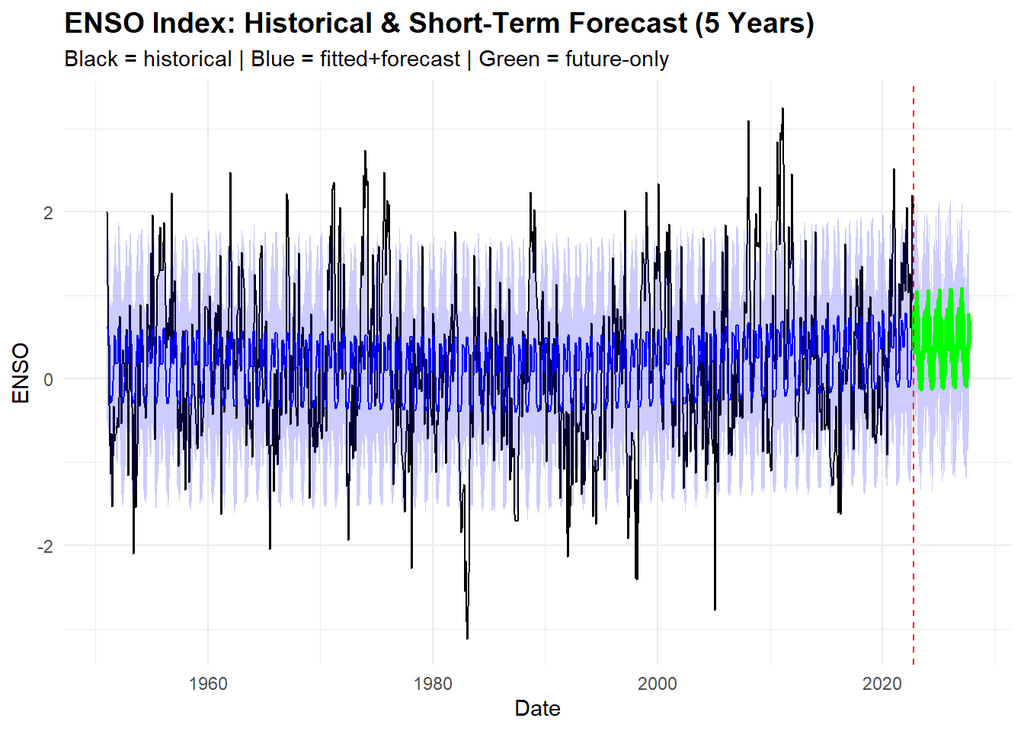

```r
library(ggplot2) # useful tool for complex plots

# Ensure dates are correctly formatted
df$ds <- as.Date(df$ds)
pdfForecast$ds <- as.Date(pdfForecast$ds)

# Group the predicted data together using a Boolean
future_only <- pdfForecast[pdfForecast$ds > max(df$ds), ]

# Craft the plot from the ground up
ggplot() +
  # Historical ENSO data
  geom_line(data = df, aes(x = ds, y = y), color = "black") + # using aes to make the plot visually appealing

  # Full forecast (fitted + predicted)
  geom_line(data = pdfForecast, aes(x = ds, y = yhat), color = "blue") +

  # Confidence intervals for full forecast
  geom_ribbon(data = pdfForecast, aes(x = ds, ymin = yhat_lower, ymax = yhat_upper),
              alpha = 0.2, fill = "blue") +

  # Future-only forecast emphasised
  geom_line(data = future_only, aes(x = ds, y = yhat), color = "green", size = 1) +

  # Vertical line separating historical vs forecast
  geom_vline(xintercept = max(df$ds), linetype = "dashed", color = "red") +

  # Labels & theme
  labs(title = "ENSO Index: Historical & Short-Term Forecast (5 Years)",
       subtitle = "Black = historical | Blue = fitted+forecast | Green = future-only",
       x = "Date",
       y = "ENSO") +
  theme_minimal() +
  theme(plot.title = element_text(face = "bold", size = 14))
```

# Chapter 5: Considering different time-frames

## Instead of considering the next five years, we could consider the next twenty.

```r
Next20 = make_future_dataframe(p_df, 7300)
pdf20 = predict(p_df, Next20)

# Let's get a general idea of pdf20
head(pdf20)
```

```
##           ds     trend additive_terms additive_terms_lower additive_terms_upper
## 1 1951-01-01 0.1965473      0.4097131            0.4097131            0.4097131
## 2 1951-02-01 0.1962428      0.4233504            0.4233504            0.4233504
## 3 1951-03-01 0.1959677      0.2206992            0.2206992            0.2206992
## 4 1951-04-01 0.1956631     -0.3886839           -0.3886839           -0.3886839
## 5 1951-05-01 0.1953684     -0.4813202           -0.4813202           -0.4813202
## 6 1951-06-01 0.1950638     -0.4674402           -0.4674402           -0.4674402
##       yearly yearly_lower yearly_upper multiplicative_terms
## 1  0.4097131    0.4097131    0.4097131                    0
## 2  0.4233504    0.4233504    0.4233504                    0
## 3  0.2206992    0.2206992    0.2206992                    0
## 4 -0.3886839   -0.3886839   -0.3886839                    0
## 5 -0.4813202   -0.4813202   -0.4813202                    0
## 6 -0.4674402   -0.4674402   -0.4674402                    0
##   multiplicative_terms_lower multiplicative_terms_upper yhat_lower yhat_upper
## 1                          0                          0 -0.6386107  1.7475158
## 2                          0                          0 -0.5713338  1.8081282
## 3                          0                          0 -0.7545292  1.6392125
## 4                          0                          0 -1.3342768  1.0279812
## 5                          0                          0 -1.4653300  0.9119753
## 6                          0                          0 -1.5015971  0.8499838
##   trend_lower trend_upper       yhat
## 1   0.1965473   0.1965473  0.6062605
## 2   0.1962428   0.1962428  0.6195931
## 3   0.1959677   0.1959677  0.4166669
## 4   0.1956631   0.1956631 -0.1930208
## 5   0.1953684   0.1953684 -0.2859518
## 6   0.1950638   0.1950638 -0.2723764
```

```r
tail(pdf20)
```

```
##              ds     trend additive_terms additive_terms_lower
## 8157 2042-09-21 0.5912854     0.01377634           0.01377634
## 8158 2042-09-22 0.5913132     0.02710047           0.02710047
## 8159 2042-09-23 0.5913411     0.04541544           0.04541544
## 8160 2042-09-24 0.5913689     0.06826638           0.06826638
## 8161 2042-09-25 0.5913968     0.09506179           0.09506179
## 8162 2042-09-26 0.5914246     0.12508960           0.12508960
##      additive_terms_upper     yearly yearly_lower yearly_upper
## 8157           0.01377634 0.01377634   0.01377634   0.01377634
## 8158           0.02710047 0.02710047   0.02710047   0.02710047
## 8159           0.04541544 0.04541544   0.04541544   0.04541544
## 8160           0.06826638 0.06826638   0.06826638   0.06826638
## 8161           0.09506179 0.09506179   0.09506179   0.09506179
## 8162           0.12508960 0.12508960   0.12508960   0.12508960
##      multiplicative_terms multiplicative_terms_lower multiplicative_terms_upper
## 8157                    0                          0                          0
## 8158                    0                          0                          0
## 8159                    0                          0                          0
## 8160                    0                          0                          0
## 8161                    0                          0                          0
## 8162                    0                          0                          0
##      yhat_lower yhat_upper trend_lower trend_upper      yhat
## 8157 -0.6448824   1.807379   0.5599148   0.6185531 0.6050617
## 8158 -0.5354302   1.752064   0.5599368   0.6185897 0.6184137
## 8159 -0.5181244   1.814661   0.5599583   0.6186263 0.6367565
## 8160 -0.5096812   1.798698   0.5599798   0.6186629 0.6596353
## 8161 -0.5198927   1.848074   0.5600013   0.6186996 0.6864585
## 8162 -0.4221443   1.867132   0.5600228   0.6187362 0.7165142
```

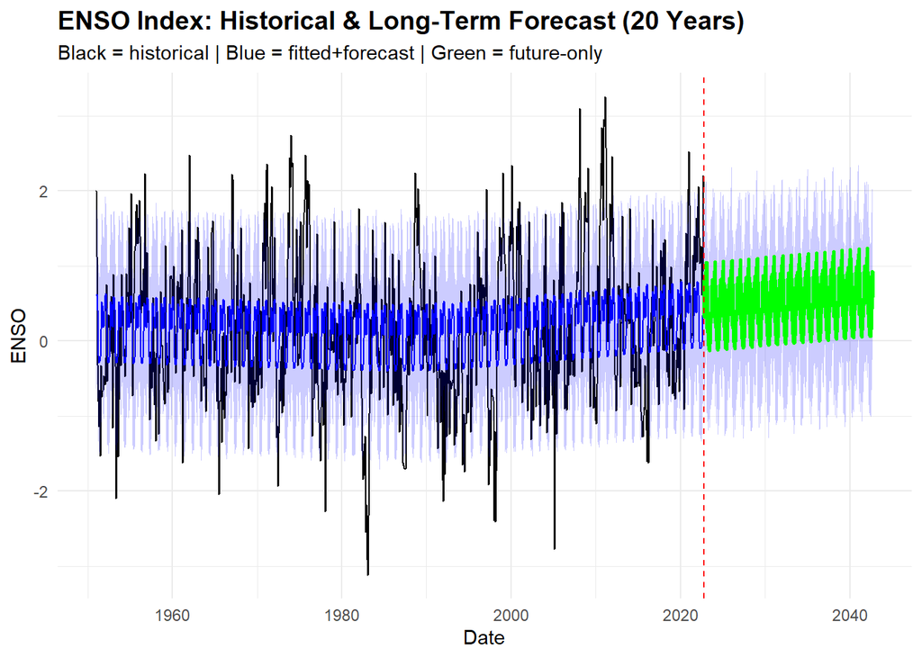

```r
library(ggplot2) # useful tool for complex plots

# Ensure dates are correctly formatted
df$ds <- as.Date(df$ds)
pdf20$ds <- as.Date(pdf20$ds)

# Group the predicted data together using a Boolean
future_only2 <- pdf20[pdf20$ds > max(df$ds), ]

# Craft the plot from the ground up
ggplot() +
  # Historical ENSO data
  geom_line(data = df, aes(x = ds, y = y), color = "black") + # using aes to make the plot visually appealing

  # Full forecast (fitted + predicted)
  geom_line(data = pdf20, aes(x = ds, y = yhat), color = "blue") +

  # Confidence intervals for full forecast
  geom_ribbon(data = pdf20, aes(x = ds, ymin = yhat_lower, ymax = yhat_upper),
              alpha = 0.2, fill = "blue") +

  # Future-only forecast emphasised
  geom_line(data = future_only2, aes(x = ds, y = yhat), color = "green", size = 1) +

  # Vertical line separating historical vs forecast
  geom_vline(xintercept = max(df$ds), linetype = "dashed", color = "red") +

  # Labels & theme
  labs(title = "ENSO Index: Historical & Long-Term Forecast (20 Years)",
       subtitle = "Black = historical | Blue = fitted+forecast | Green = future-only",
       x = "Date",
       y = "ENSO") +
  theme_minimal() +
  theme(plot.title = element_text(face = "bold", size = 14))
```

# Epilogue